# Practical

## Linear Model

Start by loading usefull libraries:

```r
library(dplyr)
library(INLA)
library(ggplot2)
library(patchwork)
library(inlabru)
# load some libraries to generate nice map plots
library(scico)
```

As our first example we consider a simple linear regression model with Gaussian observations
$$y_i\sim\mathcal{N}(\mu_i, \sigma^2), \qquad i = 1,\dots,N$$

where $\sigma^2$ is the observation error, and the mean parameter $\mu_i$ is linked to the linear predictor through an identity function:
$$\eta_i = \mu_i = \beta_0 + \beta_1 x_i$$
where $x_i$ is a covariate and $\beta_0, \beta_1$ are parameters to be estimated. We assign $\beta_0$ and $\beta_1$ a vague Gaussian prior.

To finalize the Bayesian model we assign a $\text{Gamma}(a,b)$ prior to the precision parameter $\tau = 1/\sigma^2$ and two independent Gaussian priors with mean $0$ and precision $\tau_{\beta}$ to the regression parameters $\beta_0$ and $\beta_1$.

**Question**

What is the dimension of the hyperparameter vector and latent Gaussian field?

The hyperparameter vector has dimension 1, $\pmb{\theta} = (\tau)$ while the latent Gaussian field $\pmb{u} = (\beta_0, \beta_1)$ has dimension 2, $0$ mean, and sparse precision matrix:

$$\pmb{Q} = \begin{bmatrix}
\tau_{\beta_0} & 0\\
0 & \tau_{\beta_1}
\end{bmatrix}$$
Note that, since $\beta_0$ and $\beta_1$ are fixed effecs, the precision parameters $\tau_{\beta_0}$ and $\tau_{\beta_1}$ are fixed.

**Note**

We can write the linear predictor vector $\pmb{\eta} = (\eta_1,\dots,\eta_N)$ as

$$\pmb{\eta} = \pmb{A}\pmb{u} = \pmb{A}_1\pmb{u}_1 + \pmb{A}_2\pmb{u}_2 = \begin{bmatrix}
1 \\
1\\
\vdots\\
1
\end{bmatrix} \beta_0 + \begin{bmatrix}
x_1 \\
x_2\\
\vdots\\
x_N
\end{bmatrix} \beta_1$$

Our linear predictor consists then of two components: an intercept and a slope.

In this practical we will:

- Simulate Gaussian data
- Learn how to fit the model with `inlabru`
- Learn how to set priors for linear effects $\beta_0$ and $\beta_1$
- Learn how to set the priors for the hyperparameter $\tau = 1/\sigma^2$.
- Generate predictions from the model

### **Simulate example data**

First, we simulate data from the model

$$y_i\sim\mathcal{N}(\eta_i,0.1^2), \ i = 1,\dots,100$$

with

$$\eta_i = \beta_0 + \beta_1 x_i$$

```r
beta = c(2,0.5)
sd_error = 0.1

n = 100
x = rnorm(n)
y = beta[1] + beta[2] * x + rnorm(n, sd = sd_error)

df = data.frame(y = y, x = x)
```

### **Fitting a linear regression model with `inlabru`**

**Defining model components**

The model has two parameters to be estimated $\beta_1$ and $\beta_2$. We need to define the two corresponding model components:

```r
cmp =  ~ Intercept(1) + beta_1(x, model = "linear")
```

The `cmp` object is here used to define model components. We can give them any useful names we like, in this case, `Intercept` and `beta_1`.

**Note**

Note that `Intercept()` is one of `inlabru` special names and it is used to define a global intercept. You should explicitly exclude automatic intercept when not using the special `Intercept` name, e.g.

```r
cmp =  ~ -1 + myIntercept(1) + beta_1(x, model = "linear")
```

**Observation model construction**

The next step is to construct the observation model by defining the model likelihood. The most important inputs here are the `formula`, the `family` and the `data`.

The `formula` defines how the components should be combined in order to define the model predictor.

```r
formula = y ~ Intercept + beta_1
```

**Note**

In this case we can also use the shortcut `formula = y ~ .`. This will tell `inlarbu` that the model is linear and that it is not necessary to linearize the model and assess convergence.

The likelihood is defined using the `bru_obs()` function as follows:

```r
lik =  bru_obs(formula = y ~.,
            family = "gaussian",
            data = df)
```

**Fit the model**

We fit the model using the `bru()` functions which takes as input the components and the observation model:

```r
fit.lm = bru(cmp, lik)
```

**Extract results**

The `summary()` function will give access to some basic information about model fit and estimates

```r
summary(fit.lm)
```

```
inlabru version: 2.12.0
INLA version: 25.05.26
Components:
Intercept: main = linear(1), group = exchangeable(1L), replicate = iid(1L), NULL
beta_1: main = linear(x), group = exchangeable(1L), replicate = iid(1L), NULL
Likelihoods:
  Family: 'gaussian'
    Tag: ''
    Data class: 'data.frame'
    Response class: 'numeric'
    Predictor: y ~ .
    Used components: effects[Intercept, beta_1], latent[]
Time used:
    Pre = 0.732, Running = 0.284, Post = 0.0357, Total = 1.05
Fixed effects:
           mean   sd 0.025quant 0.5quant 0.975quant  mode kld
Intercept 2.000 0.01      1.981    2.000      2.019 2.000   0
beta_1    0.509 0.01      0.490    0.509      0.528 0.509   0

Model hyperparameters:
                                          mean    sd 0.025quant 0.5quant
Precision for the Gaussian observations 108.49 15.34      80.56   107.77
                                        0.975quant   mode
Precision for the Gaussian observations     140.59 106.33

Deviance Information Criterion (DIC) ...............: -178.91
Deviance Information Criterion (DIC, saturated) ....: 105.38
Effective number of parameters .....................: 3.00

Watanabe-Akaike information criterion (WAIC) ...: -178.66
Effective number of parameters .................: 3.12

Marginal log-Likelihood:  69.99
 is computed
Posterior summaries for the linear predictor and the fitted values are computed
(Posterior marginals needs also 'control.compute=list(return.marginals.predictor=TRUE)')
```

We can see that both the intercept and slope and the error precision are correctly estimated. We can then plot the marginal posterior for $\beta_0$ as follows:

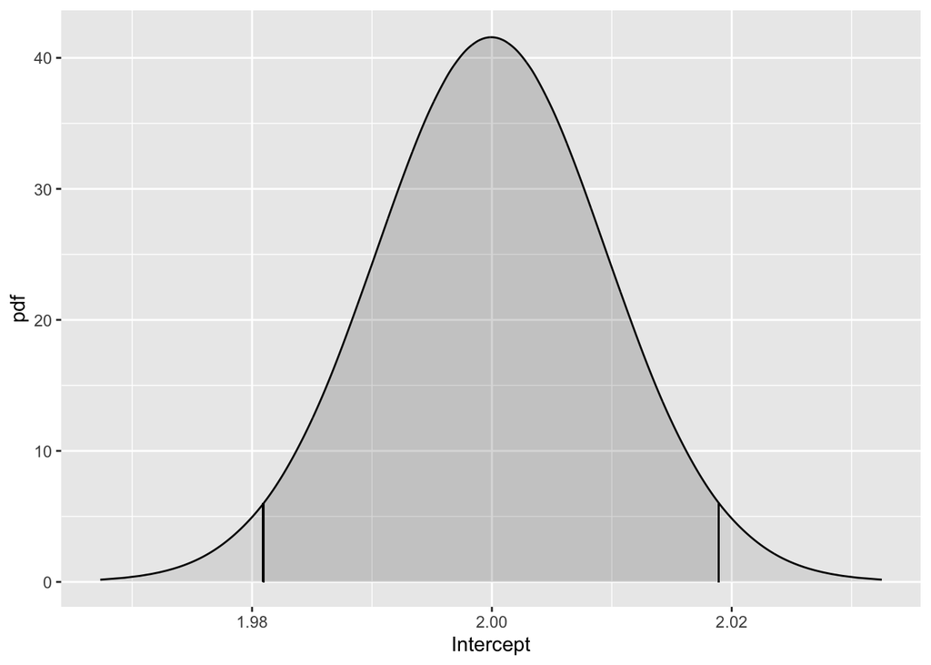

```r
plot(fit.lm, "Intercept")
```

**Task 1**

Plot the posterior marginals for $\beta_1$ and for the precision of the observation error $\pi(\tau|y)$

See the `summary()` output to check the names for the different model components.

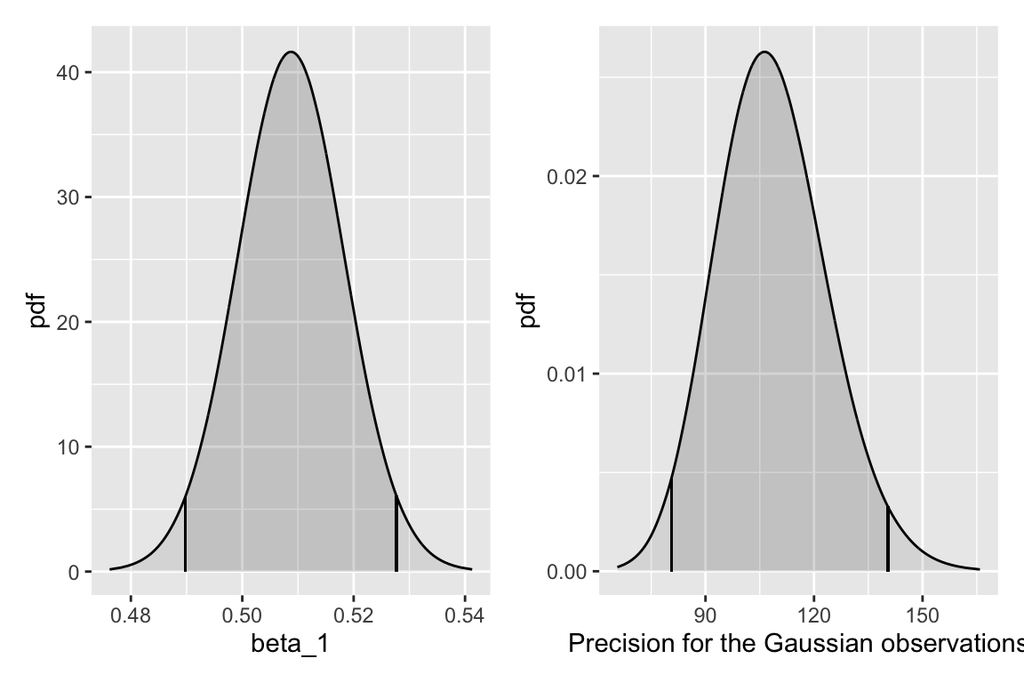

```r
plot(fit.lm, "beta_1") +
plot(fit.lm, "Precision for the Gaussian observations")
```

**Task 2**

Plot the fitted values with 95% Credible intervals.

`bru` objects information about the linear predictor can be accessed through `fit.lm$summary.fitted.values`.

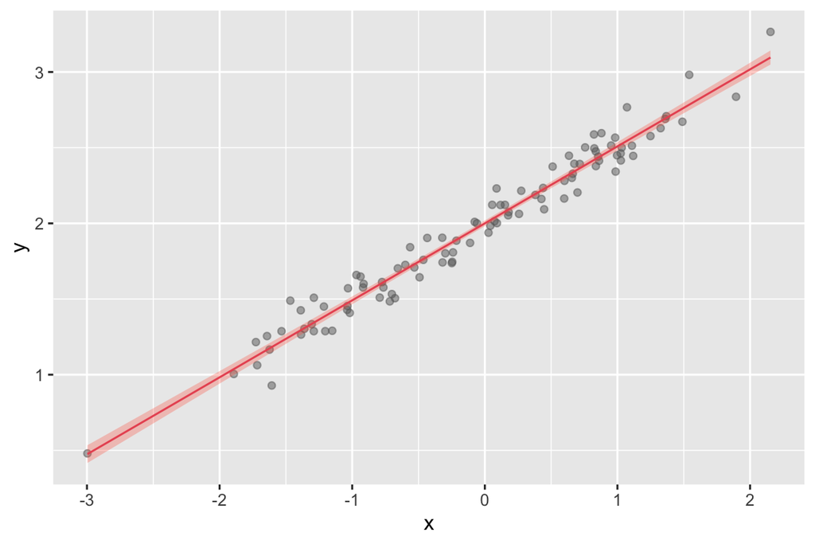

```r
df %>% mutate(post_mean = fit.lm$summary.fitted.values[1:100,"mean"],
              q25 = fit.lm$summary.fitted.values[1:100,"0.025quant"],
              q975 = fit.lm$summary.fitted.values[1:100,"0.975quant"])%>%
  ggplot()+geom_point(aes(x=x,y=y),alpha=0.5,color="grey40")+
  geom_line(aes(x=x,y=post_mean),col=2)+
  geom_ribbon(aes(x = x, ymax = q975, ymin = q25),fill="tomato", alpha = 0.3)
```

### Change the prior distributions

Until now, we have used the default priors for both the precision $\tau$ and the fixed effects $\beta_0$ and $\beta_1$. Let’s see how to customize these.

**Note**

To check which priors are used in a fitted model one can use the function `inla.prior.used()`

```r
inla.priors.used(fit.lm)
```

```
section=[family]
    tag=[INLA.Data1] component=[gaussian]
        theta1:
            parameter=[log precision]
            prior=[loggamma]
            param=[1e+00, 5e-05]
section=[linear]
    tag=[Intercept] component=[Intercept]
        beta:
            parameter=[Intercept]
            prior=[normal]
            param=[0.000, 0.001]
    tag=[beta_1] component=[beta_1]
        beta:
            parameter=[beta_1]
            prior=[normal]
            param=[0.000, 0.001]
```

From the output we see that the precision for the observation $\tau\sim\text{Gamma}(1e+00,5e-05)$ while $\beta_0$ and $\beta_1$ have precision 0.001, that is variance $1/0.001$.

**Change the precision for the linear effects**

**Task 3**

Run the model again using 0.1 as default precision for both the intercept and the slope parameter.

```r
cmp2 =  ~ Intercept(1, prec.linear = 0.1) + beta_1(x, model = "linear",
                                                   prec.linear = 0.1)

lm.fit2 = bru(cmp2, lik)
#Note that we can use the same observation model as before since both the #formula and the dataset are unchanged.
```

**Change the prior for the precision of the observation error $\tau$**

Priors on the hyperparameters of the observation model must be passed by defining argument `hyper` within `control.family` in the call to the `bru_obs()` function.

```r
prec.tau <- list(prec = list(prior = "loggamma", param = c(0.01, 0.01)))

lik2 =  bru_obs(formula = y ~.,
            family = "gaussian",
            data = df,
            control.family = list(hyper = prec.tau))

fit.lm2 = bru(cmp2, lik2)
```

### Generate model predictions

Now we can take the fitted `bru` object and use the `predict` function to produce predictions for $\mu$ given a new set of values for the model covariates or the original values used for the model fit

```r
new_data = data.frame(x = c(df$x, runif(10)),
                      y = c(df$y, rep(NA,10)))
pred = predict(fit.lm, new_data, ~ Intercept + beta_1,
               n.samples = 1000)
```

The `predict` function generate samples from the fitted model. In this case we set ehe number of samples to 1000.

**Plot**

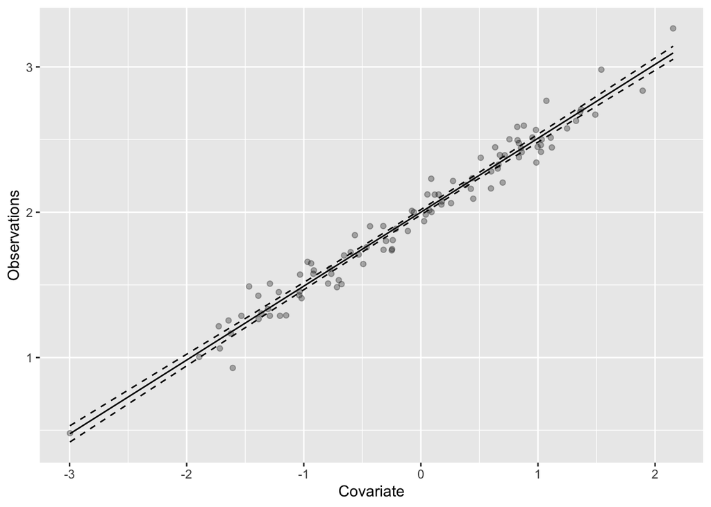

Data and 95% credible intervals

**R Code**

```r
pred %>% ggplot() +
  geom_point(aes(x,y), alpha = 0.3) +
  geom_line(aes(x,mean)) +
  geom_line(aes(x, q0.025), linetype = "dashed")+
  geom_line(aes(x, q0.975), linetype = "dashed")+
  xlab("Covariate") + ylab("Observations")
```

**Task 4**

Generate predictions for a new observation with $x = 0.45$

```r
new_data = data.frame(x = 0.45)
pred = predict(fit.lm, new_data, ~ Intercept + beta_1,
               n.samples = 1000)
```